# Valuation de Empreendimentos Tecnológicos e Projetos de Impacto

Empreendedorismo Tecnológico e Desenvolvimento Territorial · Aula 14

Prof. Dr. Luiz Diego Vidal Santos

## Unidade III Visão Geral da Aula

**01 · Fundamentos:** *Enterprise Value* vs. *Equity Value*.

**02 · FCD:** Fluxo de Caixa Descontado e Valor Terminal.

**03 · Múltiplos:** *Valuation* relativo (EV/EBITDA, P/L, EV/Receita).

**04 · Empresas Jovens:** *The Dark Side of Valuation* aplicado a *startups*.

**05 · Alta Incerteza:** Método de *Venture Capital*, Opções Reais e valor de intangíveis.

Objetivo da Aula Avaliar valor sob incerteza

Compreender as principais metodologias de *valuation* aplicáveis a empresas de base tecnológica, *startups* e projetos de impacto territorial, reconhecendo seus pressupostos, limites sob alta incerteza e conexão com a estratégia.

EV & Equity FCD & Múltiplos Opções Reais

# Fluxo de Caixa Descontado e Múltiplos

## Método Antes das Equações: O Que Significa Avaliar (*Valuation*)?

Conceito 01 Preço vs. Valor Intrínseco

- **Preço** é o que se paga em uma negociação ou bolsa em dado momento; **Valor** é a capacidade esperada de um ativo gerar caixa e benefícios ao longo do tempo.
- Em *startups* e projetos de impacto territorial, o valor não está apenas nos equipamentos atuais, mas no potencial de mercado, tecnologia e equipe.

Conceito 02 A Empresa Inteira vs. A Fatia dos Sócios

- *Enterprise Value* (EV): valor econômico total da operação do negócio (o “prédio inteiro”), independente de quem financiou.
- *Equity Value*: o que sobra para os sócios/acionistas após subtrair as dívidas líquidas (EV menos dívidas, somado ao caixa disponível).

Separar o valor operacional do negócio (**EV**) do valor atribuível aos sócios (**Equity Value**) evita distorções ao comparar empresas endividadas e desalavancadas.

## Método *Enterprise Value*, *Equity Value* e FCD (Damodaran, 2010)

**Equação Geral do FCD e Valor Terminal (Gordon)**

$$\text{EV} = \sum_{t=1}^{n} \frac{\text{FCFF}_t}{(1 + \text{WACC})^t} + \frac{\text{VT}_n}{(1 + \text{WACC})^n} \qquad \text{VT}_n = \frac{\text{FCFF}_{n+1}}{\text{WACC} - g}$$

$$\text{Equity Value} = \text{Enterprise Value} - \text{Dívida Bruta} + \text{Caixa}$$

*Restrição de perpetuidade:* $g$ nunca deve superar o crescimento nominal de longo prazo da economia.

Comparação de Mercado *Valuation* Relativo (Múltiplos)

- Compara o ativo com pares de mercado via razão preço/driver: **EV/EBITDA**, **P/L**, **EV/Receita** (comum em SaaS quando EBITDA é negativo).
- **Cuidado crítico:** múltiplos exigem controle por **crescimento esperado, risco e retorno sobre o capital (ROIC)** — empresas em territórios ou setores distintos não são diretamente comparáveis sem ajustes.

# Valuation de Startups e Opções Reais

## Decisão *The Dark Side of Valuation* e Método de *Venture Capital*

Damodaran (2018) Por que avaliar *startups* é difícil?

- Sem histórico operacional, fluxos negativos nos primeiros anos, alta mortalidade e ausência de comparáveis listadas em bolsa.
- **Método de *Venture Capital*:**
  1. Estima o *Exit Value* no ano $n$ (ex.: $8 \times \text{EBITDA}_n$);
  2. Desconta pela taxa-alvo do fundo (ex.: $35\%–50\%$ a.a.) para obter o *Post-Money Valuation* atual;
  3. $\text{Pre-Money} = \text{Post-Money} - \text{Aporte}$.

Dixit & Pindyck (1994) Introdução às Opções Reais

- O VPL tradicional assume decisão estática (“agora ou nunca”).
- **Opções Reais** capturam o valor da **flexibilidade gerencial** sob incerteza: opção de **esperar**, **expandir**, **abandonar** ou **escalar por estágios** (comum em P&D, patentes e projetos territoriais de longo prazo).

## Método Esquema: Fluxo de Caixa Descontado e Opções Reais

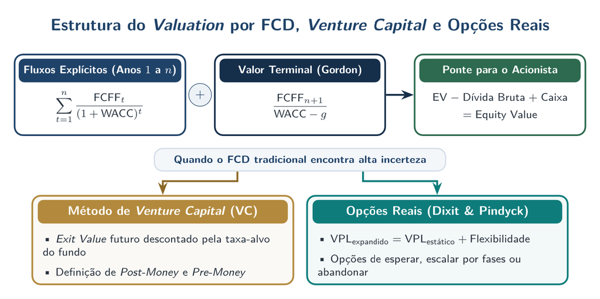

Estrutura de cálculo do Enterprise Value ao Equity Value via FCD e alternativas metodológicas sob alta incerteza (VC Method e Opções Reais).

Do *Enterprise Value* ao *Equity Value*: FCD, *VC Method* e Opções Reais Estrutura de cálculo e alternativas metodológicas para ativos tecnológicos sob alta incerteza

Quanto maior a incerteza tecnológica e o peso de intangíveis, menor a suficiência do FCD isolado e maior a relevância de estágios e opções reais.

# Preparação do Seminário Final

## Síntese Roteiro da Entrega Final (AV3 — 50%)

**Formato:** apresentação de **20 minutos** (+ **10 min** de arguição) por discente ou dupla.

**01 · Unidade I:** Diagnóstico Territorial e Ecossistêmico.

**02 · Unidade II:** Oportunidade, Modelo de Negócio / Impacto e Estratégia.

**03 · Unidade III:** Projeto de Investimento, Decisão Locacional, VPL/TIR e noções de *Valuation*.

Recomendações Base Empírica e Normas

- Tragam dados reais ou realistas do território escolhido (IBGE, SEI-BA, MapBiomas, INPI, editais FINEP/FAPESB).
- A entrega escrita final (artigo ou estudo técnico) segue as normas do **PLANTERR/UEFS**.